# Evaluación Interactiva de Matemáticas ICFES

Un experimento consiste en medir el alcance horizontal de un proyectil en funcion del angulo con el que se lanza (respecto a la horizontal). En la grafica se registran los resultados de 92 lanzamientos realizados con la misma velocidad inicial.

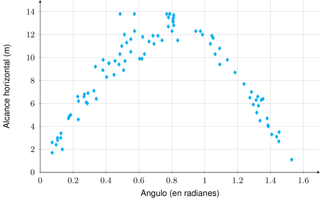

El comportamiento del alcance respecto al angulo es

de tipo lineal y con mayor dispersion cuanto mayor sea el alcance del proyectil.de tipo lineal y con mayor dispersion cuanto mayor sea el angulo de lanzamiento.parabolico y con mayor dispersion cuanto mayor sea el angulo de lanzamiento.parabolico y con mayor dispersion cuanto mayor sea el alcance del proyectil.

Para analizar el comportamiento del alcance respecto al angulo, debemos observar dos aspectos clave en la grafica de dispersion:

**1. Tipo de relacion (de tipo lineal vs parabolico):**

La relacion entre el angulo y el alcance sigue la ecuacion del movimiento de proyectiles:

$$R = \frac{v_0^2
\sin(2\theta)}{g}$$

Esta es una funcion senoidal, por lo tanto **parabolico**. En la grafica se observa claramente una forma parabolica con un maximo aproximadamente en $\theta \approx 0.78$ radianes ($\approx 45°$).

**2. Patron de dispersion:**

Observando la grafica:

- En los extremos (angulos cercanos a 0 y 1.5 radianes): los puntos estan mas concentrados
- En la zona central (alcances mayores, alrededor de 10-13 m): los puntos muestran mayor variabilidad

Esto indica que **la dispersion es proporcional a el alcance del proyectil**, no a el angulo de lanzamiento. Fisicamente, esto tiene sentido porque los errores experimentales se amplifican en trayectorias mas largas.

**Conclusion:**

El comportamiento es **parabolico** (forma parabolica) y **con mayor dispersion cuanto mayor sea el alcance del proyectil** (mayor variabilidad en valores altos de alcance).

- **Falso**. Aunque la dispersion si aumenta con el alcance del proyectil, la relacion NO es de tipo lineal.
- **Falso**. La relacion no es de tipo lineal (es parabolico) y la dispersion no depende de el angulo de lanzamiento sino de el alcance del proyectil.
- **Falso**. Si bien la relacion es parabolico, la dispersion NO aumenta con el angulo de lanzamiento sino con el alcance del proyectil.
- **Verdadero**. La relacion es parabolico (forma parabolica) y la dispersion aumenta proporcionalmente a el alcance del proyectil.

Un experimento consiste en medir el alcance horizontal de un proyectil en funcion del angulo con el que se lanza (respecto a la horizontal). En la grafica se registran los resultados de 100 lanzamientos realizados con la misma velocidad inicial.

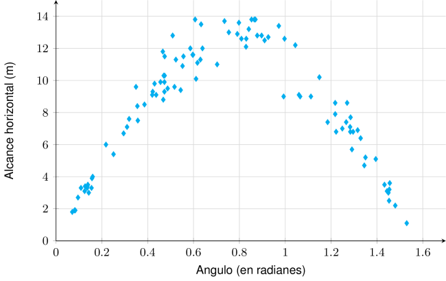

El comportamiento del alcance respecto al angulo es

proporcional y mas disperso cuanto mayor sea la inclinacion inicial.no lineal y mas disperso cuanto mayor sea la inclinacion inicial.proporcional y mas disperso cuanto mayor sea el alcance.no lineal y mas disperso cuanto mayor sea el alcance.

Para analizar el comportamiento del alcance respecto al angulo, debemos observar dos aspectos clave en la grafica de dispersion:

**1. Tipo de relacion (proporcional vs no lineal):**

La relacion entre el angulo y el alcance sigue la ecuacion del movimiento de proyectiles:

$$R = \frac{v_0^2
\sin(2\theta)}{g}$$

Esta es una funcion senoidal, por lo tanto **no lineal**. En la grafica se observa claramente una forma parabolica con un maximo aproximadamente en $\theta \approx 0.78$ radianes ($\approx 45°$).

**2. Patron de dispersion:**

Observando la grafica:

- En los extremos (angulos cercanos a 0 y 1.5 radianes): los puntos estan mas concentrados
- En la zona central (alcances mayores, alrededor de 10-13 m): los puntos muestran mayor variabilidad

Esto indica que **la dispersion es proporcional a el alcance**, no a la inclinacion inicial. Fisicamente, esto tiene sentido porque los errores experimentales se amplifican en trayectorias mas largas.

**Conclusion:**

El comportamiento es **no lineal** (forma parabolica) y **mas disperso cuanto mayor sea el alcance** (mayor variabilidad en valores altos de alcance).

- **Falso**. La relacion no es proporcional (es no lineal) y la dispersion no depende de la inclinacion inicial sino de el alcance.
- **Falso**. Si bien la relacion es no lineal, la dispersion NO aumenta con la inclinacion inicial sino con el alcance.
- **Falso**. Aunque la dispersion si aumenta con el alcance, la relacion NO es proporcional.
- **Verdadero**. La relacion es no lineal (forma parabolica) y la dispersion aumenta proporcionalmente a el alcance.

Un experimento consiste en medir el alcance horizontal de un proyectil en funcion del angulo con el que se lanza (respecto a la horizontal). En la grafica se registran los resultados de 91 lanzamientos realizados con la misma velocidad inicial.

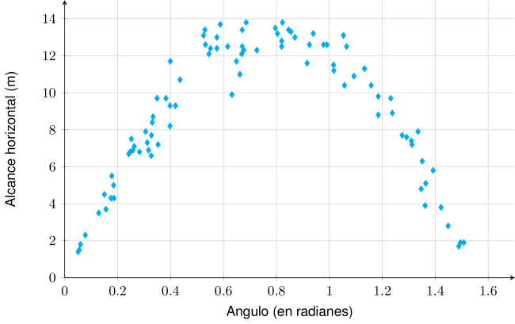

El comportamiento del alcance respecto al angulo es

de tipo lineal y mas variable cuanto mayor sea la inclinacion inicial.no proporcional y mas variable cuanto mayor sea la inclinacion inicial.no proporcional y mas variable cuanto mayor sea el alcance del proyectil.de tipo lineal y mas variable cuanto mayor sea el alcance del proyectil.

Para analizar el comportamiento del alcance respecto al angulo, debemos observar dos aspectos clave en la grafica de dispersion:

**1. Tipo de relacion (de tipo lineal vs no proporcional):**

La relacion entre el angulo y el alcance sigue la ecuacion del movimiento de proyectiles:

$$R = \frac{v_0^2
\sin(2\theta)}{g}$$

Esta es una funcion senoidal, por lo tanto **no proporcional**. En la grafica se observa claramente una forma parabolica con un maximo aproximadamente en $\theta \approx 0.78$ radianes ($\approx 45°$).

**2. Patron de dispersion:**

Observando la grafica:

- En los extremos (angulos cercanos a 0 y 1.5 radianes): los puntos estan mas concentrados
- En la zona central (alcances mayores, alrededor de 10-13 m): los puntos muestran mayor variabilidad

Esto indica que **la dispersion es proporcional a el alcance del proyectil**, no a la inclinacion inicial. Fisicamente, esto tiene sentido porque los errores experimentales se amplifican en trayectorias mas largas.

**Conclusion:**

El comportamiento es **no proporcional** (forma parabolica) y **mas variable cuanto mayor sea el alcance del proyectil** (mayor variabilidad en valores altos de alcance).

- **Falso**. La relacion no es de tipo lineal (es no proporcional) y la dispersion no depende de la inclinacion inicial sino de el alcance del proyectil.
- **Falso**. Si bien la relacion es no proporcional, la dispersion NO aumenta con la inclinacion inicial sino con el alcance del proyectil.
- **Verdadero**. La relacion es no proporcional (forma parabolica) y la dispersion aumenta proporcionalmente a el alcance del proyectil.
- **Falso**. Aunque la dispersion si aumenta con el alcance del proyectil, la relacion NO es de tipo lineal.

Un experimento consiste en medir el alcance horizontal de un proyectil en funcion del angulo con el que se lanza (respecto a la horizontal). En la grafica se registran los resultados de 98 lanzamientos realizados con la misma velocidad inicial.

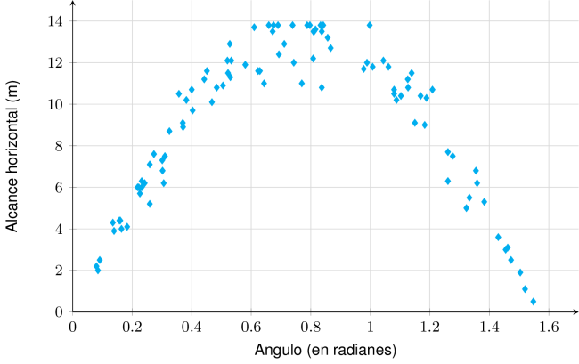

El comportamiento del alcance respecto al angulo es

proporcional y con mayor variabilidad cuanto mayor sea el angulo.parabolico y con mayor variabilidad cuanto mayor sea el angulo.parabolico y con mayor variabilidad cuanto mayor sea el alcance del proyectil.proporcional y con mayor variabilidad cuanto mayor sea el alcance del proyectil.

Para analizar el comportamiento del alcance respecto al angulo, debemos observar dos aspectos clave en la grafica de dispersion:

**1. Tipo de relacion (proporcional vs parabolico):**

La relacion entre el angulo y el alcance sigue la ecuacion del movimiento de proyectiles:

$$R = \frac{v_0^2
\sin(2\theta)}{g}$$

Esta es una funcion senoidal, por lo tanto **parabolico**. En la grafica se observa claramente una forma parabolica con un maximo aproximadamente en $\theta \approx 0.78$ radianes ($\approx 45°$).

**2. Patron de dispersion:**

Observando la grafica:

- En los extremos (angulos cercanos a 0 y 1.5 radianes): los puntos estan mas concentrados
- En la zona central (alcances mayores, alrededor de 10-13 m): los puntos muestran mayor variabilidad

Esto indica que **la dispersion es proporcional a el alcance del proyectil**, no a el angulo. Fisicamente, esto tiene sentido porque los errores experimentales se amplifican en trayectorias mas largas.

**Conclusion:**

El comportamiento es **parabolico** (forma parabolica) y **con mayor variabilidad cuanto mayor sea el alcance del proyectil** (mayor variabilidad en valores altos de alcance).

- **Falso**. La relacion no es proporcional (es parabolico) y la dispersion no depende de el angulo sino de el alcance del proyectil.
- **Falso**. Si bien la relacion es parabolico, la dispersion NO aumenta con el angulo sino con el alcance del proyectil.
- **Verdadero**. La relacion es parabolico (forma parabolica) y la dispersion aumenta proporcionalmente a el alcance del proyectil.
- **Falso**. Aunque la dispersion si aumenta con el alcance del proyectil, la relacion NO es proporcional.

Un experimento consiste en medir el alcance horizontal de un proyectil en funcion del angulo con el que se lanza (respecto a la horizontal). En la grafica se registran los resultados de 107 lanzamientos realizados con la misma velocidad inicial.

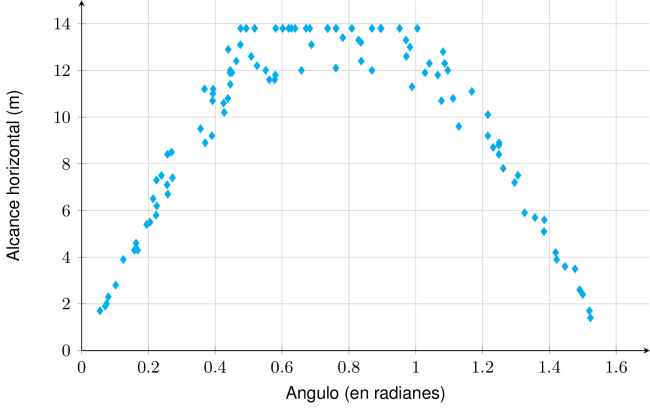

El comportamiento del alcance respecto al angulo es

de tipo no lineal y con mayor dispersion cuanto mayor sea el alcance.de tipo no lineal y con mayor dispersion cuanto mayor sea el angulo de lanzamiento.de tipo lineal y con mayor dispersion cuanto mayor sea el angulo de lanzamiento.de tipo lineal y con mayor dispersion cuanto mayor sea el alcance.

Para analizar el comportamiento del alcance respecto al angulo, debemos observar dos aspectos clave en la grafica de dispersion:

**1. Tipo de relacion (de tipo lineal vs de tipo no lineal):**

La relacion entre el angulo y el alcance sigue la ecuacion del movimiento de proyectiles:

$$R = \frac{v_0^2
\sin(2\theta)}{g}$$

Esta es una funcion senoidal, por lo tanto **de tipo no lineal**. En la grafica se observa claramente una forma parabolica con un maximo aproximadamente en $\theta \approx 0.78$ radianes ($\approx 45°$).

**2. Patron de dispersion:**

Observando la grafica:

- En los extremos (angulos cercanos a 0 y 1.5 radianes): los puntos estan mas concentrados
- En la zona central (alcances mayores, alrededor de 10-13 m): los puntos muestran mayor variabilidad

Esto indica que **la dispersion es proporcional a el alcance**, no a el angulo de lanzamiento. Fisicamente, esto tiene sentido porque los errores experimentales se amplifican en trayectorias mas largas.

**Conclusion:**

El comportamiento es **de tipo no lineal** (forma parabolica) y **con mayor dispersion cuanto mayor sea el alcance** (mayor variabilidad en valores altos de alcance).

- **Verdadero**. La relacion es de tipo no lineal (forma parabolica) y la dispersion aumenta proporcionalmente a el alcance.
- **Falso**. Si bien la relacion es de tipo no lineal, la dispersion NO aumenta con el angulo de lanzamiento sino con el alcance.
- **Falso**. La relacion no es de tipo lineal (es de tipo no lineal) y la dispersion no depende de el angulo de lanzamiento sino de el alcance.
- **Falso**. Aunque la dispersion si aumenta con el alcance, la relacion NO es de tipo lineal.

Un experimento consiste en medir el alcance horizontal de un proyectil en funcion del angulo con el que se lanza (respecto a la horizontal). En la grafica se registran los resultados de 96 lanzamientos realizados con la misma velocidad inicial.

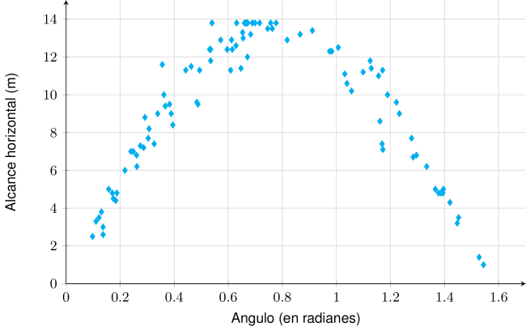

El comportamiento del alcance respecto al angulo es

no proporcional y mas variable cuanto mayor sea la distancia recorrida.lineal y mas variable cuanto mayor sea el angulo.no proporcional y mas variable cuanto mayor sea el angulo.lineal y mas variable cuanto mayor sea la distancia recorrida.

Para analizar el comportamiento del alcance respecto al angulo, debemos observar dos aspectos clave en la grafica de dispersion:

**1. Tipo de relacion (lineal vs no proporcional):**

La relacion entre el angulo y el alcance sigue la ecuacion del movimiento de proyectiles:

$$R = \frac{v_0^2
\sin(2\theta)}{g}$$

Esta es una funcion senoidal, por lo tanto **no proporcional**. En la grafica se observa claramente una forma parabolica con un maximo aproximadamente en $\theta \approx 0.78$ radianes ($\approx 45°$).

**2. Patron de dispersion:**

Observando la grafica:

- En los extremos (angulos cercanos a 0 y 1.5 radianes): los puntos estan mas concentrados
- En la zona central (alcances mayores, alrededor de 10-13 m): los puntos muestran mayor variabilidad

Esto indica que **la dispersion es proporcional a la distancia recorrida**, no a el angulo. Fisicamente, esto tiene sentido porque los errores experimentales se amplifican en trayectorias mas largas.

**Conclusion:**

El comportamiento es **no proporcional** (forma parabolica) y **mas variable cuanto mayor sea la distancia recorrida** (mayor variabilidad en valores altos de alcance).

- **Verdadero**. La relacion es no proporcional (forma parabolica) y la dispersion aumenta proporcionalmente a la distancia recorrida.
- **Falso**. La relacion no es lineal (es no proporcional) y la dispersion no depende de el angulo sino de la distancia recorrida.
- **Falso**. Si bien la relacion es no proporcional, la dispersion NO aumenta con el angulo sino con la distancia recorrida.
- **Falso**. Aunque la dispersion si aumenta con la distancia recorrida, la relacion NO es lineal.

Un experimento consiste en medir el alcance horizontal de un proyectil en funcion del angulo con el que se lanza (respecto a la horizontal). En la grafica se registran los resultados de 104 lanzamientos realizados con la misma velocidad inicial.

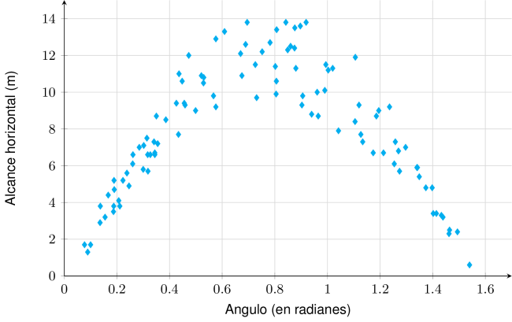

El comportamiento del alcance respecto al angulo es

no proporcional y con mayor dispersion cuanto mayor sea el alcance horizontal.no proporcional y con mayor dispersion cuanto mayor sea el angulo de lanzamiento.directamente proporcional y con mayor dispersion cuanto mayor sea el alcance horizontal.directamente proporcional y con mayor dispersion cuanto mayor sea el angulo de lanzamiento.

Para analizar el comportamiento del alcance respecto al angulo, debemos observar dos aspectos clave en la grafica de dispersion:

**1. Tipo de relacion (directamente proporcional vs no proporcional):**

La relacion entre el angulo y el alcance sigue la ecuacion del movimiento de proyectiles:

$$R = \frac{v_0^2
\sin(2\theta)}{g}$$

Esta es una funcion senoidal, por lo tanto **no proporcional**. En la grafica se observa claramente una forma parabolica con un maximo aproximadamente en $\theta \approx 0.78$ radianes ($\approx 45°$).

**2. Patron de dispersion:**

Observando la grafica:

- En los extremos (angulos cercanos a 0 y 1.5 radianes): los puntos estan mas concentrados
- En la zona central (alcances mayores, alrededor de 10-13 m): los puntos muestran mayor variabilidad

Esto indica que **la dispersion es proporcional a el alcance horizontal**, no a el angulo de lanzamiento. Fisicamente, esto tiene sentido porque los errores experimentales se amplifican en trayectorias mas largas.

**Conclusion:**

El comportamiento es **no proporcional** (forma parabolica) y **con mayor dispersion cuanto mayor sea el alcance horizontal** (mayor variabilidad en valores altos de alcance).

- **Verdadero**. La relacion es no proporcional (forma parabolica) y la dispersion aumenta proporcionalmente a el alcance horizontal.
- **Falso**. Si bien la relacion es no proporcional, la dispersion NO aumenta con el angulo de lanzamiento sino con el alcance horizontal.
- **Falso**. Aunque la dispersion si aumenta con el alcance horizontal, la relacion NO es directamente proporcional.
- **Falso**. La relacion no es directamente proporcional (es no proporcional) y la dispersion no depende de el angulo de lanzamiento sino de el alcance horizontal.

Un experimento consiste en medir el alcance horizontal de un proyectil en funcion del angulo con el que se lanza (respecto a la horizontal). En la grafica se registran los resultados de 94 lanzamientos realizados con la misma velocidad inicial.

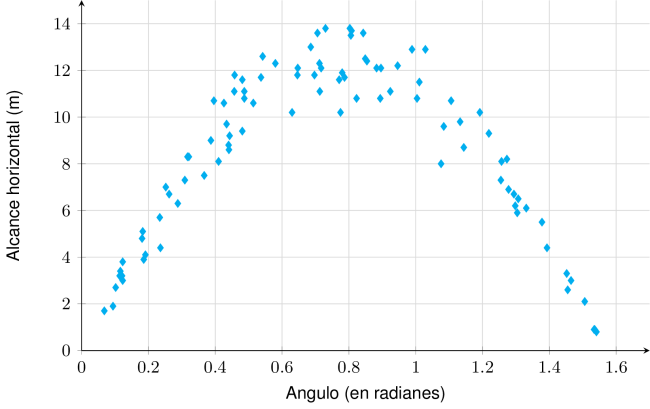

El comportamiento del alcance respecto al angulo es

de tipo no lineal y con mayor variabilidad cuanto mayor sea el angulo inicial.lineal y con mayor variabilidad cuanto mayor sea la distancia recorrida.lineal y con mayor variabilidad cuanto mayor sea el angulo inicial.de tipo no lineal y con mayor variabilidad cuanto mayor sea la distancia recorrida.

Para analizar el comportamiento del alcance respecto al angulo, debemos observar dos aspectos clave en la grafica de dispersion:

**1. Tipo de relacion (lineal vs de tipo no lineal):**

La relacion entre el angulo y el alcance sigue la ecuacion del movimiento de proyectiles:

$$R = \frac{v_0^2
\sin(2\theta)}{g}$$

Esta es una funcion senoidal, por lo tanto **de tipo no lineal**. En la grafica se observa claramente una forma parabolica con un maximo aproximadamente en $\theta \approx 0.78$ radianes ($\approx 45°$).

**2. Patron de dispersion:**

Observando la grafica:

- En los extremos (angulos cercanos a 0 y 1.5 radianes): los puntos estan mas concentrados
- En la zona central (alcances mayores, alrededor de 10-13 m): los puntos muestran mayor variabilidad

Esto indica que **la dispersion es proporcional a la distancia recorrida**, no a el angulo inicial. Fisicamente, esto tiene sentido porque los errores experimentales se amplifican en trayectorias mas largas.

**Conclusion:**

El comportamiento es **de tipo no lineal** (forma parabolica) y **con mayor variabilidad cuanto mayor sea la distancia recorrida** (mayor variabilidad en valores altos de alcance).

- **Falso**. Si bien la relacion es de tipo no lineal, la dispersion NO aumenta con el angulo inicial sino con la distancia recorrida.
- **Falso**. Aunque la dispersion si aumenta con la distancia recorrida, la relacion NO es lineal.
- **Falso**. La relacion no es lineal (es de tipo no lineal) y la dispersion no depende de el angulo inicial sino de la distancia recorrida.
- **Verdadero**. La relacion es de tipo no lineal (forma parabolica) y la dispersion aumenta proporcionalmente a la distancia recorrida.

Un experimento consiste en medir el alcance horizontal de un proyectil en funcion del angulo con el que se lanza (respecto a la horizontal). En la grafica se registran los resultados de 96 lanzamientos realizados con la misma velocidad inicial.

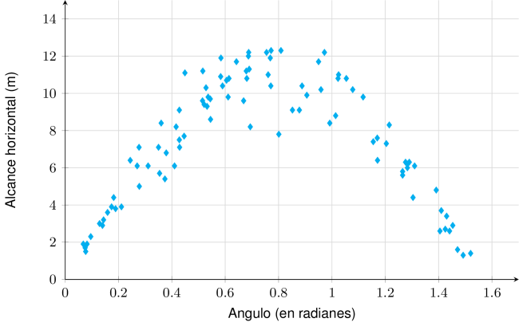

El comportamiento del alcance respecto al angulo es

directamente proporcional y mas disperso cuanto mayor sea la inclinacion inicial.de tipo no lineal y mas disperso cuanto mayor sea la inclinacion inicial.de tipo no lineal y mas disperso cuanto mayor sea la distancia recorrida.directamente proporcional y mas disperso cuanto mayor sea la distancia recorrida.

Para analizar el comportamiento del alcance respecto al angulo, debemos observar dos aspectos clave en la grafica de dispersion:

**1. Tipo de relacion (directamente proporcional vs de tipo no lineal):**

La relacion entre el angulo y el alcance sigue la ecuacion del movimiento de proyectiles:

$$R = \frac{v_0^2
\sin(2\theta)}{g}$$

Esta es una funcion senoidal, por lo tanto **de tipo no lineal**. En la grafica se observa claramente una forma parabolica con un maximo aproximadamente en $\theta \approx 0.78$ radianes ($\approx 45°$).

**2. Patron de dispersion:**

Observando la grafica:

- En los extremos (angulos cercanos a 0 y 1.5 radianes): los puntos estan mas concentrados
- En la zona central (alcances mayores, alrededor de 10-13 m): los puntos muestran mayor variabilidad

Esto indica que **la dispersion es proporcional a la distancia recorrida**, no a la inclinacion inicial. Fisicamente, esto tiene sentido porque los errores experimentales se amplifican en trayectorias mas largas.

**Conclusion:**

El comportamiento es **de tipo no lineal** (forma parabolica) y **mas disperso cuanto mayor sea la distancia recorrida** (mayor variabilidad en valores altos de alcance).

- **Falso**. La relacion no es directamente proporcional (es de tipo no lineal) y la dispersion no depende de la inclinacion inicial sino de la distancia recorrida.
- **Falso**. Si bien la relacion es de tipo no lineal, la dispersion NO aumenta con la inclinacion inicial sino con la distancia recorrida.
- **Verdadero**. La relacion es de tipo no lineal (forma parabolica) y la dispersion aumenta proporcionalmente a la distancia recorrida.
- **Falso**. Aunque la dispersion si aumenta con la distancia recorrida, la relacion NO es directamente proporcional.

Un experimento consiste en medir el alcance horizontal de un proyectil en funcion del angulo con el que se lanza (respecto a la horizontal). En la grafica se registran los resultados de 110 lanzamientos realizados con la misma velocidad inicial.

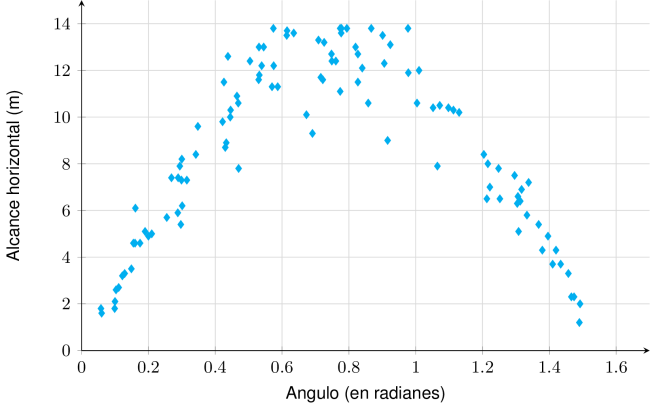

El comportamiento del alcance respecto al angulo es

de tipo lineal y con mayor variabilidad cuanto mayor sea el alcance del proyectil.no proporcional y con mayor variabilidad cuanto mayor sea el alcance del proyectil.de tipo lineal y con mayor variabilidad cuanto mayor sea la inclinacion inicial.no proporcional y con mayor variabilidad cuanto mayor sea la inclinacion inicial.

Para analizar el comportamiento del alcance respecto al angulo, debemos observar dos aspectos clave en la grafica de dispersion:

**1. Tipo de relacion (de tipo lineal vs no proporcional):**

La relacion entre el angulo y el alcance sigue la ecuacion del movimiento de proyectiles:

$$R = \frac{v_0^2
\sin(2\theta)}{g}$$

Esta es una funcion senoidal, por lo tanto **no proporcional**. En la grafica se observa claramente una forma parabolica con un maximo aproximadamente en $\theta \approx 0.78$ radianes ($\approx 45°$).

**2. Patron de dispersion:**

Observando la grafica:

- En los extremos (angulos cercanos a 0 y 1.5 radianes): los puntos estan mas concentrados
- En la zona central (alcances mayores, alrededor de 10-13 m): los puntos muestran mayor variabilidad

Esto indica que **la dispersion es proporcional a el alcance del proyectil**, no a la inclinacion inicial. Fisicamente, esto tiene sentido porque los errores experimentales se amplifican en trayectorias mas largas.

**Conclusion:**

El comportamiento es **no proporcional** (forma parabolica) y **con mayor variabilidad cuanto mayor sea el alcance del proyectil** (mayor variabilidad en valores altos de alcance).

- **Falso**. Aunque la dispersion si aumenta con el alcance del proyectil, la relacion NO es de tipo lineal.
- **Verdadero**. La relacion es no proporcional (forma parabolica) y la dispersion aumenta proporcionalmente a el alcance del proyectil.
- **Falso**. La relacion no es de tipo lineal (es no proporcional) y la dispersion no depende de la inclinacion inicial sino de el alcance del proyectil.
- **Falso**. Si bien la relacion es no proporcional, la dispersion NO aumenta con la inclinacion inicial sino con el alcance del proyectil.